# Homework2 疫情数据分析

20210980108 颜帆

## **背景介绍**：

从 2020 年 1 月 1 日起，截至 2020 年 1 月 23 日（武汉封城前），数以百万的曾在此期间滞留过武汉的人群（简称：风险携带者），在并不完全明了疫情严重性的情况下，离开武汉前往全国乃至世界各地，并对流入区域的疫情产生了可见的影响。由于可能和被确诊的患者曾经密切接触等原因，他们是潜在的携带新冠病毒的高风险人群。因此，对非武汉地区来说，辖区内的这批人格外值得密切关注。数据收集了截止至2020年1月30日，354个新冠疫情爆发的直管区域的累计病例。同时，收集并统计了对应地区人群在1月23日封城前到访武汉市内的比例及重点地区到访情况。

## 研究目的：

通过某公司手机App收集的人群地理位置数据及公开疫情数据，分析累计确诊病例与2020年1月23日（武汉封城）前武汉流出的高风险人群的关联。

## 数据说明：

**数据说明：**

- **因变量**为累计确诊人数（数值型变量）。该数目收集自截止至1月30日卫健委发布的累计确诊病例情况。
- **解释变量**包括：

1) 地区：表示统计的某一直管区域；

2) 省份：表示地区对应的省份；

3) 累计武汉滞留时间：该地区内1月23日前到访武汉人群的累计滞留时间，时间单位为秒；

4) 风险携带者比例：该地区到访武汉的人群占所有风险携带者的百分比，如5.6256306表示5.6256306%；

5) 武汉62家定点医院到访比例：该地区到访武汉62家定点医院人群百分比，如0.4397199表示0.4397199%；

6) 华南海鲜市场到访比例：该地区到访华南海鲜市场人群的百分比，如0.0143371表示0.0143371%；

7) 机场到访比例：该地区到访机场人群的百分比，如0.0002625表示0.0002625%；

8) 火车站到访比例：该地区到访火车站人群的百分比，如0.0004342表示0.0004342%。

**分析任务：**

1. 读入数据并了解各变量的含义；
2. 统计各个省份的累计确诊人数，选择人数排名前十的省份，绘制累计人数柱状图，并作简要分析；
3. 绘制省份-风险携带者比例绘制箱线图，其中省份选择湖北省、浙江省、广东省、河南省和湖南省，并作简要分析。
4. 以累计确诊人数为因变量，其他指标为解释性变量，建立回归模型并对模型进行诊断，分析累计确诊人数的影响因素，观察最终的回归系数并尝试对系数进行解释。

## 实验部分

将代码实验部分划分成分析任务的四个小任务。

### 任务一

导入相应的库，读入csv数据并了解各变量的含义。

```python
import pandas as pd
import numpy as np
import matplotlib.pyplot as plt
from sklearn.linear_model import LinearRegression
from sklearn.metrics import r2_score
import statsmodels.api as sm
```

```python
df = pd.read_csv("wuhan_covid_190130.csv",encoding="gbk")
df.drop([len(df)-1],inplace=True) #注意到表只有最后一个数据为缺失值，删掉
df.shape
```

```
(354, 9)
```

```python
df.head(10)
```

|  | 地区 | 省份 | 累计武汉滞留时间 | 风险携带者比例 | 武汉62家定点医院到访比例 | 华南海鲜市场到访比例 | 机场到访比例 | 火车站到访比例 | 累计确诊人数 |
| --- | --- | --- | --- | --- | --- | --- | --- | --- | --- |
| 0 | 陕西省地区1 | 陕西省 | 1.017910e+09 | 0.301702 | 0.005563 | 0.000212 | 0.000051 | 0.0 | 10.0 |
| 1 | 安徽省地区1 | 安徽省 | 3.658795e+09 | 0.458449 | 0.020304 | 0.000707 | 0.000061 | 0.0 | 18.0 |
| 2 | 河南省地区1 | 河南省 | 1.207890e+09 | 0.255642 | 0.008744 | 0.000333 | 0.000000 | 0.0 | 16.0 |
| 3 | 重庆市地区1 | 重庆市 | 1.347042e+08 | 0.082892 | 0.001434 | 0.000071 | 0.000000 | 0.0 | 1.0 |
| 4 | 内蒙古地区1 | 内蒙古自治区 | 1.240102e+08 | 0.015670 | 0.000636 | 0.000081 | 0.000000 | 0.0 | 2.0 |
| 5 | 四川省地区1 | 四川省 | 6.386943e+08 | 0.165309 | 0.001928 | 0.000111 | 0.000000 | 0.0 | 4.0 |
| 6 | 甘肃省地区1 | 甘肃省 | 3.905419e+08 | 0.054491 | 0.001020 | 0.000030 | 0.000000 | 0.0 | 1.0 |
| 7 | 广西壮族自治区地区1 | 广西壮族自治区 | 2.701934e+08 | 0.095967 | 0.001222 | 0.000051 | 0.000000 | 0.0 | 2.0 |
| 8 | 安徽省地区2 | 安徽省 | 6.377411e+08 | 0.155556 | 0.004069 | 0.000222 | 0.000252 | 0.0 | 8.0 |
| 9 | 内蒙古地区2 | 内蒙古自治区 | 1.838580e+08 | 0.034348 | 0.001040 | 0.000000 | 0.000010 | 0.0 | 3.0 |

可看到，数据包含九个变量，其中因变量为累计确诊人数，是我们需要用回归模型去预测的变量；解释变量有八个，分别为地区、省份、累计武汉滞留时间、风险携带者比例、武汉62家定点医院到访比例、华南海鲜市场到访比例、机场到访比例和火车站到访比例，是我们用于建模分析是否对因变量有影响的八个解释变量。各变量的含义在数据说明中皆有介绍。

## 任务二

统计各个省份的累计确诊人数，选择人数排名前十的省份，绘制累计人数柱状图，并作简要分析；

```python
df1 = df.groupby(by=['省份'],as_index=False)['累计确诊人数'].sum()  #按省份划分数据，对累计确诊人数求和
df1 = df1.sort_values('累计确诊人数',ascending = False)  #统计了各个省份的累计确诊人数后，按降序排名
df1.head(10)
```

|  | 省份 | 累计确诊人数 |
| --- | --- | --- |
| 20 | 湖北省 | 2325.0 |
| 18 | 浙江省 | 428.0 |
| 11 | 广东省 | 354.0 |
| 17 | 河南省 | 278.0 |
| 21 | 湖南省 | 277.0 |
| 8 | 安徽省 | 200.0 |
| 26 | 重庆市 | 174.0 |
| 15 | 江西省 | 162.0 |
| 9 | 山东省 | 158.0 |
| 5 | 四川省 | 142.0 |

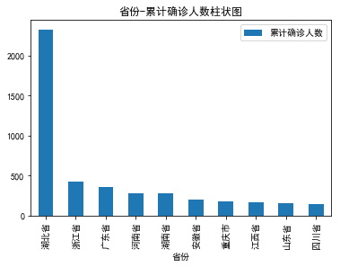

```python
df1.head(10).plot.bar(x= '省份',title = '省份-累计确诊人数柱状图')  #选取确诊人数排名前十个最多的省份，画出柱状图
```

## 任务三

绘制省份-风险携带者比例绘制箱线图，其中省份选择湖北省、浙江省、广东省、河南省和湖南省，并作简要分析。

```
Text(0.5,1,'省份-风险携带者比例箱线图')
```

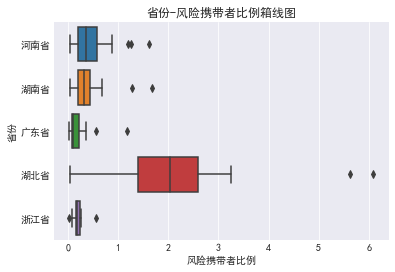

```python
import seaborn as sns
import matplotlib.pyplot as plt
sns.set_style('darkgrid', {'font.sans-serif':['SimHei', 'Arial']})#设置图表背景颜色字体
df2 = df[df['省份'].isin(['湖北省','浙江省','广东省','河南省','湖南省'])]
sns.boxplot(data=df2,x='风险携带者比例',y='省份')
plt.title('省份-风险携带者比例箱线图')
```

可以看出，对这五个省而言，风险携带者比例最高的是湖北省，且比例中位数远高于其他省份；而且，可以看到每个省的每个地区的风险携带者比例也有所不同，对于异常值点，猜测应该是在该地区存在超级传染者，是较为严重的疫情区域，导致风险携带者比例高于其他地区。

## 任务四

以累计确诊人数为因变量，其他指标为解释性变量，建立回归模型并对模型进行诊断，分析累计确诊人数的影响因素，观察最终的回归系数并尝试对系数进行解释。 首先，对数据划分为训练集和测试集，其次，对整个模型做多元线性回归分析（包含所有的解释变量），然后根据AIC值，逐步回归筛选出对因变量有显著影响的变量，再利用选出的变量建模，与全部变量的回归模型进行比较，对其回归系数进行解释，然后在测试集上的算出MSE，最后对模型进行诊断。

```python
import pandas as pd
import numpy as np
import statsmodels.formula.api as smf
#from sklearn.cross_validation import train_test_split
from sklearn.model_selection import train_test_split
from sklearn.metrics import mean_squared_error
import matplotlib.pyplot as plt
```

```python
df.describe() #查看数据描述
```

|  | 累计武汉滞留时间 | 风险携带者比例 | 武汉62家定点医院到访比例 | 华南海鲜市场到访比例 | 机场到访比例 | 火车站到访比例 | 累计确诊人数 |
| --- | --- | --- | --- | --- | --- | --- | --- |
| count | 3.540000e+02 | 354.000000 | 354.000000 | 354.000000 | 354.000000 | 354.000000 | 354.000000 |
| mean | 2.351991e+09 | 0.271231 | 0.013161 | 0.000461 | 0.001266 | 0.001808 | 15.435028 |
| std | 9.711322e+09 | 0.594823 | 0.044153 | 0.001621 | 0.004606 | 0.009194 | 41.715447 |
| min | 1.276685e+07 | 0.002797 | 0.000091 | 0.000000 | 0.000000 | 0.000000 | 1.000000 |
| 25% | 2.037907e+08 | 0.049238 | 0.001232 | 0.000030 | 0.000000 | 0.000000 | 2.000000 |
| 50% | 4.615500e+08 | 0.109385 | 0.003105 | 0.000111 | 0.000000 | 0.000000 | 5.000000 |
| 75% | 1.037240e+09 | 0.231057 | 0.007807 | 0.000263 | 0.000230 | 0.000000 | 11.000000 |
| max | 1.093430e+11 | 6.087219 | 0.489828 | 0.021112 | 0.037337 | 0.088192 | 496.000000 |

```python
# 抽样--构造训练集和测试集
Train,Test = train_test_split(df, train_size = 0.8, random_state=1234)
```

```python
fit1 = smf.ols('累计确诊人数~  累计武汉滞留时间 +风险携带者比例 + 武汉62家定点医院到访比例 + 华南海鲜市场到访比例 + 机场到访比例 + 火车站到访比例', data = Train).fit()
# 模型概览的反馈
fit1.summary()
```

OLS Regression Results

| Dep. Variable: | 累计确诊人数 | R-squared: | 0.900 |
| --- | --- | --- | --- |
| Model: | OLS | Adj. R-squared: | 0.898 |
| Method: | Least Squares | F-statistic: | 416.3 |
| Date: | Mon, 29 Mar 2021 | Prob (F-statistic): | 4.02e-135 |
| Time: | 22:11:22 | Log-Likelihood: | -1154.3 |
| No. Observations: | 283 | AIC: | 2323. |
| Df Residuals: | 276 | BIC: | 2348. |
| Df Model: | 6 |  |  |
| Covariance Type: | nonrobust |  |  |

|  | coef | std err | t | P>\|t\| | [0.025 | 0.975] |
| --- | --- | --- | --- | --- | --- | --- |
| Intercept | 3.4064 | 1.116 | 3.051 | 0.003 | 1.209 | 5.604 |
| 累计武汉滞留时间 | 3.855e-09 | 3.84e-10 | 10.037 | 0.000 | 3.1e-09 | 4.61e-09 |
| 风险携带者比例 | 15.0485 | 7.288 | 2.065 | 0.040 | 0.701 | 29.396 |
| 武汉62家定点医院到访比例 | 19.0633 | 179.429 | 0.106 | 0.915 | -334.161 | 372.287 |
| 华南海鲜市场到访比例 | -3939.3363 | 3263.712 | -1.207 | 0.228 | -1.04e+04 | 2485.595 |
| 机场到访比例 | 436.1205 | 233.999 | 1.864 | 0.063 | -24.529 | 896.770 |
| 火车站到访比例 | 202.1113 | 130.664 | 1.547 | 0.123 | -55.114 | 459.337 |

| Omnibus: | 347.115 | Durbin-Watson: | 2.089 |
| --- | --- | --- | --- |
| Prob(Omnibus): | 0.000 | Jarque-Bera (JB): | 33621.590 |
| Skew: | 5.243 | Prob(JB): | 0.00 |
| Kurtosis: | 55.358 | Cond. No. | 3.99e+13 |

```python
from statsmodels.formula.api import ols
#定义向前逐步回归函数
def forward_select(data,target):
    #variate=set(data.columns)  #将字段名转换成字典类型
    variate = {'华南海鲜市场到访比例','机场到访比例','武汉62家定点医院到访比例','火车站到访比例','累计武汉滞留时间','累计确诊人数', '风险携带者比例','省份'}
    variate.remove(target)  #去掉因变量的字段名
    selected=[]
    current_score,best_new_score=float('inf'),float('inf')  #目前的分数和最好分数初始值都为无穷大（因为AIC越小越好）
    #循环筛选变量
    while variate:
        aic_with_variate=[]
        for candidate in variate:  #逐个遍历自变量
            formula="{}~{}".format(target,"+".join(selected+[candidate]))  #将自变量名连接起来
            aic=ols(formula=formula,data=data).fit().aic  #利用ols训练模型得出aic值
            aic_with_variate.append((aic,candidate))  #将第每一次的aic值放进空列表
        aic_with_variate.sort(reverse=True)  #降序排序aic值
        best_new_score,best_candidate=aic_with_variate.pop()  #最好的aic值等于删除列表的最后一个值，以及最好的自变量等于列表最后一个自变量
        if current_score>best_new_score:  #如果目前的aic值大于最好的aic值
            variate.remove(best_candidate)  #移除加进来的变量名，即第二次循环时，不考虑此自变量了
            selected.append(best_candidate)  #将此自变量作为加进模型中的自变量
            current_score=best_new_score  #最新的分数等于最好的分数
            print("aic is {},continuing!".format(current_score))  #输出最小的aic值
        else:
            print("for selection over!")
            break
    formula="{}~{}".format(target,"+".join(selected))  #最终的模型式子
    print("final formula is {}".format(formula))
    model=ols(formula=formula,data=data).fit()
    return(model)
```

```python
forward_select(data=df,target="累计确诊人数")
```

```
aic is 2947.6409518123482,continuing!
aic is 2909.4730354065664,continuing!
aic is 2891.9367144646903,continuing!
aic is 2880.5216054444572,continuing!
aic is 2880.4431110809683,continuing!
for selection over!
final formula is 累计确诊人数~累计武汉滞留时间+风险携带者比例+省份+机场到访比例+火车站到访比例
```

```
<statsmodels.regression.linear_model.RegressionResultsWrapper at 0x7fd342dbb9b0>
```

```python
#利用aic前向逐步回归筛选出来的变量建模
fit2 = smf.ols('累计确诊人数~  累计武汉滞留时间+风险携带者比例+机场到访比例+火车站到访比例+省份', data = Train).fit()
# 模型概览的反馈
fit2.summary()
```

OLS Regression Results

| Dep. Variable: | 累计确诊人数 | R-squared: | 0.922 |
| --- | --- | --- | --- |
| Model: | OLS | Adj. R-squared: | 0.912 |
| Method: | Least Squares | F-statistic: | 89.16 |
| Date: | Mon, 29 Mar 2021 | Prob (F-statistic): | 5.34e-119 |
| Time: | 22:11:23 | Log-Likelihood: | -1119.9 |
| No. Observations: | 283 | AIC: | 2308. |
| Df Residuals: | 249 | BIC: | 2432. |
| Df Model: | 33 |  |  |
| Covariance Type: | nonrobust |  |  |

|  | coef | std err | t | P>\|t\| | [0.025 | 0.975] |
| --- | --- | --- | --- | --- | --- | --- |
| Intercept | 1.2379 | 4.092 | 0.303 | 0.763 | -6.822 | 9.297 |
| 省份[T.云南省] | 2.0797 | 6.545 | 0.318 | 0.751 | -10.811 | 14.970 |
| 省份[T.内蒙古自治区] | -0.5601 | 6.539 | -0.086 | 0.932 | -13.438 | 12.318 |
| 省份[T.北京市] | 2.6324 | 6.958 | 0.378 | 0.706 | -11.072 | 16.337 |
| 省份[T.吉林省] | -0.9092 | 6.539 | -0.139 | 0.890 | -13.787 | 11.969 |
| 省份[T.四川省] | -0.0200 | 5.454 | -0.004 | 0.997 | -10.761 | 10.722 |
| 省份[T.天津市] | 1.6281 | 6.283 | 0.259 | 0.796 | -10.747 | 14.003 |
| 省份[T.宁夏回族自治区] | 5.4430 | 14.104 | 0.386 | 0.700 | -22.335 | 33.221 |
| 省份[T.安徽省] | 2.8751 | 5.587 | 0.515 | 0.607 | -8.128 | 13.878 |
| 省份[T.山东省] | 5.1345 | 5.482 | 0.937 | 0.350 | -5.663 | 15.932 |
| 省份[T.山西省] | -0.7867 | 6.292 | -0.125 | 0.901 | -13.178 | 11.605 |
| 省份[T.广东省] | 10.3585 | 5.817 | 1.781 | 0.076 | -1.098 | 21.815 |
| 省份[T.广西壮族自治区] | 1.7798 | 6.552 | 0.272 | 0.786 | -11.124 | 14.683 |
| 省份[T.新疆维吾尔自治区] | 0.1803 | 8.803 | 0.020 | 0.984 | -17.158 | 17.519 |
| 省份[T.江苏省] | 0.2887 | 5.795 | 0.050 | 0.960 | -11.125 | 11.702 |
| 省份[T.江西省] | 3.5762 | 6.668 | 0.536 | 0.592 | -9.556 | 16.709 |
| 省份[T.河北省] | -0.9610 | 6.207 | -0.155 | 0.877 | -13.187 | 11.265 |
| 省份[T.河南省] | -3.5986 | 6.054 | -0.594 | 0.553 | -15.523 | 8.325 |
| 省份[T.浙江省] | 33.2178 | 5.945 | 5.587 | 0.000 | 21.509 | 44.927 |
| 省份[T.海南省] | 0.7946 | 6.084 | 0.131 | 0.896 | -11.188 | 12.777 |
| 省份[T.湖北省] | -11.4859 | 7.512 | -1.529 | 0.128 | -26.282 | 3.310 |
| 省份[T.湖南省] | 4.6401 | 5.812 | 0.798 | 0.425 | -6.807 | 16.087 |
| 省份[T.甘肃省] | -0.4242 | 6.080 | -0.070 | 0.944 | -12.398 | 11.550 |
| 省份[T.福建省] | 1.9354 | 6.867 | 0.282 | 0.778 | -11.590 | 15.461 |
| 省份[T.贵州省] | -5.5672 | 6.541 | -0.851 | 0.396 | -18.450 | 7.316 |
| 省份[T.辽宁省] | -0.1859 | 6.084 | -0.031 | 0.976 | -12.168 | 11.796 |
| 省份[T.重庆市] | 1.8132 | 4.816 | 0.376 | 0.707 | -7.672 | 11.299 |
| 省份[T.陕西省] | -0.7615 | 5.951 | -0.128 | 0.898 | -12.481 | 10.958 |
| 省份[T.青海省] | 2.6373 | 14.103 | 0.187 | 0.852 | -25.140 | 30.414 |
| 省份[T.黑龙江省] | 1.2815 | 5.908 | 0.217 | 0.828 | -10.355 | 12.918 |
| 累计武汉滞留时间 | 3.751e-09 | 3.31e-10 | 11.348 | 0.000 | 3.1e-09 | 4.4e-09 |
| 风险携带者比例 | 10.8159 | 5.918 | 1.828 | 0.069 | -0.839 | 22.471 |
| 机场到访比例 | 613.5525 | 223.294 | 2.748 | 0.006 | 173.768 | 1053.337 |
| 火车站到访比例 | 123.9716 | 128.187 | 0.967 | 0.334 | -128.498 | 376.441 |

| Omnibus: | 282.298 | Durbin-Watson: | 2.084 |
| --- | --- | --- | --- |
| Prob(Omnibus): | 0.000 | Jarque-Bera (JB): | 16367.492 |
| Skew: | 3.817 | Prob(JB): | 0.00 |
| Kurtosis: | 39.466 | Cond. No. | 3.00e+12 |

```python
fit3 = smf.ols('累计确诊人数~ 累计武汉滞留时间+风险携带者比例+机场到访比例 ', data = Train).fit()
# 模型概览的反馈
fit3.summary()
```

OLS Regression Results

| Dep. Variable: | 累计确诊人数 | R-squared: | 0.899 |
| --- | --- | --- | --- |
| Model: | OLS | Adj. R-squared: | 0.898 |
| Method: | Least Squares | F-statistic: | 825.1 |
| Date: | Mon, 29 Mar 2021 | Prob (F-statistic): | 2.42e-138 |
| Time: | 22:11:23 | Log-Likelihood: | -1156.9 |
| No. Observations: | 283 | AIC: | 2322. |
| Df Residuals: | 279 | BIC: | 2336. |
| Df Model: | 3 |  |  |
| Covariance Type: | nonrobust |  |  |

|  | coef | std err | t | P>\|t\| | [0.025 | 0.975] |
| --- | --- | --- | --- | --- | --- | --- |
| Intercept | 3.6233 | 1.060 | 3.417 | 0.001 | 1.536 | 5.710 |
| 累计武汉滞留时间 | 3.457e-09 | 2.83e-10 | 12.205 | 0.000 | 2.9e-09 | 4.02e-09 |
| 风险携带者比例 | 11.9350 | 4.706 | 2.536 | 0.012 | 2.670 | 21.200 |
| 机场到访比例 | 639.9030 | 212.567 | 3.010 | 0.003 | 221.463 | 1058.343 |

| Omnibus: | 341.134 | Durbin-Watson: | 2.095 |
| --- | --- | --- | --- |
| Prob(Omnibus): | 0.000 | Jarque-Bera (JB): | 30906.033 |
| Skew: | 5.109 | Prob(JB): | 0.00 |
| Kurtosis: | 53.166 | Cond. No. | 2.59e+12 |

对回归系数而言，该模型认为机场到访比例、风险携带者比例和累计武汉滞留时间均对累计确诊人数起到正面影响，回归系数大于0，这是合理的，常识上，我们可以理解，一个地区的人在武汉滞留的时间越长、到访机场的人数越多、风险携带者的比例越大，就更容易传染新冠，导致确诊人数上升。

```python
#在测试集上预测
pred = fit3.predict(exog = Test)
RMSE = np.sqrt(mean_squared_error(Test.累计确诊人数, pred))
print('模型的预测效果：RMES=%.4f\n' %RMSE)
```

```
模型的预测效果：RMES=14.8700
```

```python
lm = smf.ols('累计确诊人数~ 累计武汉滞留时间+风险携带者比例+机场到访比例 ', data = df).fit() #在整个数据集上拟合
```

```
      fitted  index    resids  std_resids
0  11.134708   10.0 -1.134708   -0.078746
1  21.636880   18.0 -3.636880   -0.252390
2  10.866989   16.0  5.133011    0.356217
3   4.726897    1.0 -3.726897   -0.258637
4   3.539354    2.0 -1.539354   -0.106827
```

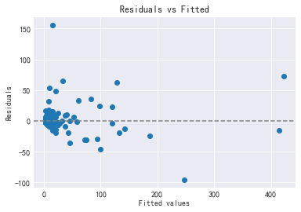

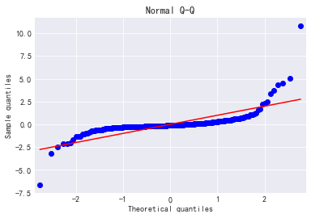

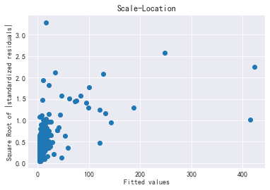

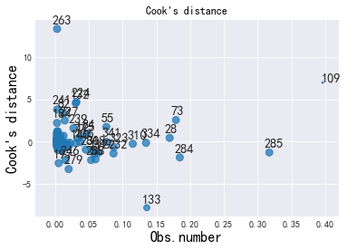

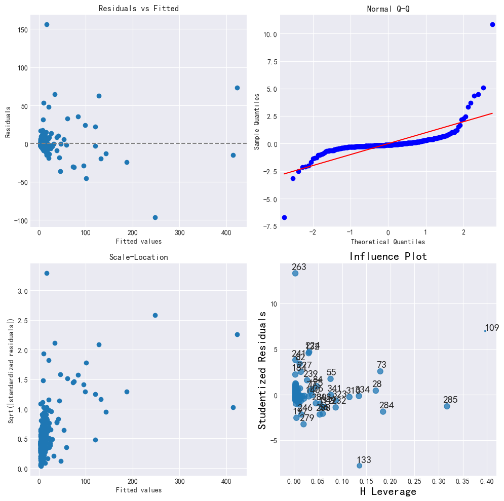

```python
import os
import math
import pandas as pd
import numpy as np
import matplotlib
import matplotlib.pyplot as plt
import statsmodels.api as sm
import statsmodels.formula.api as smf

results = pd.DataFrame({'index': df.累计确诊人数, # y实际值
                        'resids': lm.resid, # 残差
                        'std_resids': lm.resid_pearson, # 方差标准化的残差
                        'fitted': lm.predict() # y预测值
                       })
print(results.head())

# 1. 图表分别显示
## raw residuals vs. fitted
# 残差拟合图：横坐标是拟合值，纵坐标是残差。
residsvfitted = plt.plot(results['fitted'], results['resids'],  'o')
l = plt.axhline(y = 0, color = 'grey', linestyle = 'dashed') # 绘制y=0水平线
plt.xlabel('Fitted values')
plt.ylabel('Residuals')
plt.title('Residuals vs Fitted')
plt.show(residsvfitted)


## q-q plot
# 残差QQ图：用来描述残差是否符合正态分布。
qqplot = sm.qqplot(results['std_resids'], line='s')
plt.xlabel('Theoretical quantiles')
plt.ylabel('Sample quantiles')
plt.title('Normal Q-Q')
plt.show(qqplot)


## scale-location
# 标准化的残差对拟合值：对标准化残差平方根和拟合值作图，横坐标是拟合值，纵坐标是标准化后的残差平方根。
scalelocplot = plt.plot(results['fitted'], abs(results['std_resids'])**.5,  'o')
plt.xlabel('Fitted values')
plt.ylabel('Square Root of |standardized residuals|')
plt.title('Scale-Location')
plt.show(scalelocplot)


## residuals vs. leverage
# 标准化残差对杠杆值:通常用Cook距离度量的回归影响点。
residsvlevplot = sm.graphics.influence_plot(lm, criterion = 'Cooks', size = 2)
plt.xlabel('Obs.number')
plt.ylabel("Cook's distance")
plt.title("Cook's distance")
plt.show(residsvlevplot)
plt.close()

fig = plt.figure(figsize = (10, 10), dpi = 100)

ax1 = fig.add_subplot(2, 2, 1)
ax1.plot(results['fitted'], results['resids'],  'o')
l = plt.axhline(y = 0, color = 'grey', linestyle = 'dashed')
ax1.set_xlabel('Fitted values')
ax1.set_ylabel('Residuals')
ax1.set_title('Residuals vs Fitted')


ax2 = fig.add_subplot(2, 2, 2)
sm.qqplot(results['std_resids'], line='s', ax = ax2)
ax2.set_title('Normal Q-Q')


ax3 = fig.add_subplot(2, 2, 3)
ax3.plot(results['fitted'], abs(results['std_resids'])**.5,  'o')
ax3.set_xlabel('Fitted values')
ax3.set_ylabel('Sqrt(|standardized residuals|)')
ax3.set_title('Scale-Location')

ax4 = fig.add_subplot(2, 2, 4)
sm.graphics.influence_plot(lm, criterion = 'Cooks', size = 2, ax = ax4)

plt.tight_layout()
```

[figure not shown]